# Reproduction of Hurricane Harvey Flooding GEOG120 Lab Problem

### Authors

- Colman Bashore*, cbashore@middlebury.edu, @colman-bashore, Middlebury College

* Corresponding author and creator

### Abstract

This study is a reproduction of a Middebury Geography Indroductory GIS Lab problem titled "Exposure to Environmental Hazards: Hurricane Harvey." The original study focused on comparing levels of flooding across block groups of different majority demographics. The original study used the desktop GIS QGIS to determine the majority racial group in every block group in Harris County, Texas and then compared these data to the extent of flooding from Hurricane Harvey. This reproduction study aims to reproduce the same results from the original lab problem using a Python computation notebook (ipynb) as opposed to a desktop GIS workflow. The notebook will potentially serve as an opportunity to demonstrate using Python to complete simple GIS problems in the context of an introductory Human Geography with GIS class.

[Link to original study prompt](https://drive.google.com/file/d/1l_bylAyBrcuvR5PYj_I3jSKbu04dz5Wh/view)

### Study metadata

#### Original study spatio-temporal metadata

- `Spatial Coverage`: Harris County, Texas [OpenStreetMap Link](https://www.openstreetmap.org/relation/1560395)
- `Spatial Resolution`: Census Block Group Level
- `Spatial Reference System`: EPSG:6587
- `Temporal Coverage`: September 2017
- `Temporal Resolution`: ACS 5 year estimates

## Study design

The study is setup to be an educational example. The primary research question is which regions defined by majority racial/ethnic group had the most flooding during Hurricane Harvey. It used a zonal statistic to calculate the amount of flooding in each region of Harris County. The original study is a QGIS workflow, and this replication uses a ipynb python notebook.

## Computational environment

Maintaining a reproducible computational environment requires some conscious choices in package management.

Please refer to `requirements.txt` for details.

```python
# Import modules, define directories

from pyhere import here
import pandas as pd
import geopandas as gpd
import folium
import matplotlib
import numpy as np
import rasterio
from rasterio.plot import show
import fiona
from rasterstats import zonal_stats
from matplotlib import pyplot as plt



# You can define your own shortcuts for file paths:
path = {
    "dscr": here("data", "scratch"),
    "drpub": here("data", "raw", "public"),
    "drpriv": here("data", "raw", "private"),
    "ddpub": here("data", "derived", "public"),
    "ddpriv": here("data", "derived", "private"),
    "rfig": here("results", "figures"),
    "roth": here("results", "other"),
    "rtab": here("results", "tables"),
    "dmet": here("data", "metadata")
}
```

### Data and variables

Describe the **data sources** and **variables** to be used. Data sources may include plans for observing and recording **primary data** or descriptions of **secondary data**. For secondary data sources with numerous variables, the analysis plan authors may focus on documenting only the variables intended for use in the study.

Each of the next subsections describes one data source.

### blockgroups.shp

- `Title`: blockgroups.shp
- `Abstract`: Shapefile containing the geometry and GEOID over every Census block group in Harris County, Texas.
- `Spatial Coverage`: Harris County, Texas. [OpenStreetMap Link](https://www.openstreetmap.org/relation/1560395)
- `Spatial Resolution`: Census Block Group
- `Spatial Reference System`: EPSG: 6587
- `Temporal Coverage`: N/A
- `Temporal Resolution`: N/A
- `Lineage`: United States Census Bureau delineation, gathered through US Census API https://www.census.gov/developers/
- `Distribution`: Distributed publicly indefinetely by the US Census.
- `Constraints`: None
- `Data Quality`: Opening in a graphical GIS like QGIS and verifying existence of all block groups.
- `Variables`: For each variable, enter the following information. If you have two or more variables per data source, you may want to present this information in table form (shown below)
  - `Label`: GEOID
  - `Alias`: GEOID
  - `Definition`: Unique identifier for each block group
  - `Type`: Integer
  - `Accuracy`: One per block group.
  - `Domain`: 482011000001 to 482019801001
  - `Missing Data Value(s)`: N/A
  - `Missing Data Frequency`: None for GEOID

Other variables are not significant for this analysis Prior observation: - [x] metadata and descriptive statistics have been observed

##### Import blockgroups.shp

```python
blockgroups = gpd.read_file(here(path["drpub"], "blockgroups.shp"))

blockgroups = gpd.GeoDataFrame(blockgroups)

blockgroups.head()
```

|  | STATEFP | COUNTYFP | TRACTCE | BLKGRPCE | AFFGEOID | GEOID | LSAD | ALAND | AWATER | GEONAME | geometry |
| --- | --- | --- | --- | --- | --- | --- | --- | --- | --- | --- | --- |
| 0 | 48 | 201 | 311000 | 1 | 1500000US482013110001 | 482013110001 | BG | 616969.0 | 47009.0 | Block Group 1, Census Tract 3110, Harris Count... | POLYGON ((958404.137 4217699.295, 958413.144 4... |
| 1 | 48 | 201 | 311000 | 4 | 1500000US482013110004 | 482013110004 | BG | 408595.0 | 25333.0 | Block Group 4, Census Tract 3110, Harris Count... | POLYGON ((957048.814 4217692.784, 957496.427 4... |
| 2 | 48 | 201 | 311100 | 1 | 1500000US482013111001 | 482013111001 | BG | 1018525.0 | 213804.0 | Block Group 1, Census Tract 3111, Harris Count... | POLYGON ((958975.179 4217311.881, 958892.738 4... |
| 3 | 48 | 201 | 311100 | 3 | 1500000US482013111003 | 482013111003 | BG | 484061.0 | 36045.0 | Block Group 3, Census Tract 3111, Harris Count... | POLYGON ((958773.280 4216120.376, 959779.865 4... |
| 4 | 48 | 201 | 311100 | 4 | 1500000US482013111004 | 482013111004 | BG | 547376.0 | 0.0 | Block Group 4, Census Tract 3111, Harris Count... | POLYGON ((958756.220 4216618.402, 959659.603 4... |

#### blockgroup_demographic_data.csv

| Label | Alias | Definition | Type | Accuracy | Domain | Missing Data Value(s) | Missing Data Frequency |
| --- | --- | --- | --- | --- | --- | --- | --- |
| GEOID | GEOID | Unique identifier for each block group | Integer | N/A | 482011000001 to 482019801001 | N/A | None |
| BO3002_001 | Total Population | Number of people in the block group | Integer | See ACS | 9-21758 | N/A | None |
| BO3002_003 | White Population | Number of people in the White racial/ethnic group in the block group | Integer | See ACS | 0-9199 | N/A | None |
| BO3002_004 | Black Population | Number of people in the Black racial/ethnic group in the block group | Integer | See ACS | 0-5258 | N/A | None |
| BO3002_006 | Asian Population | Number of people in the Asian racial/ethnic group in the block group | Integer | See ACS | 0-3418 | N/A | None |
| BO3002_012 | Latinx Population | Number of people in the Latinx racial/ethnic group in the block group | Integer | See ACS | 0-11408 | N/A | None |

```python
blockgroup_demographic_data = pd.read_csv(here(path["drpub"],'blockgroup_demographic_data.csv'), dtype=str,encoding='latin-1')


blockgroup_demographic_data.head()
```

|  | GEOID | B03002_001 | B03002_002 | B03002_003 | B03002_004 | B03002_005 | B03002_006 | B03002_007 | B03002_008 | B03002_009 | ... | B03002_012 | B03002_013 | B03002_014 | B03002_015 | B03002_016 | B03002_017 | B03002_018 | B03002_019 | B03002_020 | B03002_021 |
| --- | --- | --- | --- | --- | --- | --- | --- | --- | --- | --- | --- | --- | --- | --- | --- | --- | --- | --- | --- | --- | --- |
| 0 | 482013110001 | 583 | 0 | 0 | 0 | 0 | 0 | 0 | 0 | 0 | ... | 583 | 573 | 0 | 0 | 0 | 0 | 10 | 0 | 0 | 0 |
| 1 | 482013110004 | 1869 | 22 | 22 | 0 | 0 | 0 | 0 | 0 | 0 | ... | 1847 | 1818 | 0 | 0 | 0 | 0 | 29 | 0 | 0 | 0 |
| 2 | 482013111001 | 1046 | 11 | 11 | 0 | 0 | 0 | 0 | 0 | 0 | ... | 1035 | 895 | 4 | 0 | 0 | 0 | 136 | 0 | 0 | 0 |
| 3 | 482013111003 | 1639 | 112 | 112 | 0 | 0 | 0 | 0 | 0 | 0 | ... | 1527 | 1192 | 0 | 0 | 0 | 0 | 315 | 20 | 0 | 20 |
| 4 | 482013111004 | 1759 | 48 | 0 | 16 | 0 | 32 | 0 | 0 | 0 | ... | 1711 | 1476 | 11 | 7 | 0 | 0 | 173 | 44 | 44 | 0 |

5 rows × 22 columns

#### actual_flood_10.tif

- `Title`: actual_flood_10.tif
- `Abstract`: Raster image of Harris County where 1's represent flooded area from Hurricane Harvey and and nodata (raster equivalent of NULL) in all other locations
- `Spatial Coverage`: Harris County, Texas. [OpenStreetMap Link](https://www.openstreetmap.org/relation/1560395)
- `Spatial Resolution`: 10 meter resolution
- `Spatial Reference System`: EPSG: 6587
- `Temporal Coverage`: September 2017
- `Temporal Resolution`: Worth investigating more, a specific day after the flooding.
- `Lineage`: I recieved this data from the GEOG 120 professors. The original sources are: The Flood Observatory https://floodobservatory.colorado.edu/ and the Harris County Flood Control District: https://www.hcfcd.org/Hurricane-Harvey. The steps taken from the original source to the version I recieved are unclear.
- `Distribution`: This exact file may not be publicly available.
- `Constraints`: Middlebury Course Material
- `Data Quality`: Inspect in QGIS.
- `Variables`: Only has one Band. 1 = Flooded. Nodata = Not flooded.

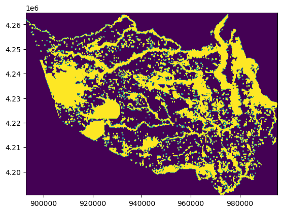

```python
actual_flood_10 = rasterio.open(here(path["drpub"],'actual_flood_10.tif'))

ax = show((actual_flood_10, 1))
```

### Bias and threats to validity

One of the main geographic threat to validity in this study is the modifiable areal unit problem. In the case of the original study the data sources are aggregated at the level of census block groups. In many cases the unit of aggregation used for a study can dramatically change the output of an analysis. For example, the map of majority racial groups in Harris County aggregated at the block group level would be much more complex than a map at the tract level but it would not be as detailed may show different trends than a map produced with data at the block level. The original study unit size is based upon the scale of data available, which often determines the unit used. However, we cannot be sure that the results of our analysis wouldn't be different if we used a finer unit of analysis, therefore the unit of aggregation is a threat to validity in this study. Additionally, another threat to this study is the confusion of spatial and a-spatial causation. Flooding is an example of a variable that is often considered to be based exlusivily on the physical geographic of a place. However, this may lead to a lack of focus on variables such as emergency preparedness that may impact the extent of flooding. Another threat to validity is the common assumption that all locations within a delineated region are the same. In the case of the Harvey flooding study we may see that a region that has a predominantly white population has a lot of flooding, but we are not taking into consideration the distribution of population within that area and cannot tell whether the flooding in that region is overlapping with the white population or if there are other factors at play such as flooding in undeveloped wetlands within the region, which would not have a significant human geography impact. Finally, there may be a boundary effect from the border of Harris County. The northwest border of Harris County is a river, thus it follows that the lowland area surrounding it would be more likely to flood. Thus, by not extending the extent of the study, we may see higher flooded percentages in regions that touch this border.

### Data transformations

Describe all data transformations planned to prepare data sources for analysis. This section should explain with the fullest detail possible how to transform data from the **raw** state at the time of acquisition or observation, to the pre-processed **derived** state ready for the main analysis. Including steps to check and mitigate sources of **bias** and **threats to validity**. The method may anticipate **contingencies**, e.g. tests for normality and alternative decisions to make based on the results of the test. More specifically, all the **geographic** and **variable** transformations required to prepare input data as described in the data and variables section above to match the study's spatio-temporal characteristics as described in the study metadata and study design sections. Visual workflow diagrams may help communicate the methodology in this section.

Examples of **geographic** transformations include coordinate system transformations, aggregation, disaggregation, spatial interpolation, distance calculations, zonal statistics, etc.

Examples of **variable** transformations include standardization, normalization, constructed variables, imputation, classification, etc.

Be sure to include any steps planned to **exclude** observations with *missing* or *outlier* data, to **group** observations by *attribute* or *geographic* criteria, or to **impute** missing data or apply spatial or temporal **interpolation**.

#### Goal 1: Load census data into block groups

```python
bg_merged = blockgroups.merge(blockgroup_demographic_data, on = "GEOID", how = "left")

bgData = gpd.GeoDataFrame(bg_merged)

bgData.rename(
  columns={
    'B03002_001': 'Total',
    'B03002_003' : 'White',
    'B03002_004' : 'Black',
    'B03002_006' : 'Asian',
    'B03002_012' : 'Latinx',
  },
  inplace=True
)

bgData  = bgData.drop(columns=['STATEFP', 'COUNTYFP', 'TRACTCE', 'BLKGRPCE', 'AFFGEOID','LSAD', 'ALAND', 'AWATER', 'GEONAME','B03002_002','B03002_005','B03002_007', 'B03002_008','B03002_009', 'B03002_010', 'B03002_011','B03002_013','B03002_014', 'B03002_015', 'B03002_016', 'B03002_017', 'B03002_018','B03002_019', 'B03002_020', 'B03002_021'])

# bgData = bgData.astype(
#      {'GEOID': 'int','Total': 'float', 'White': 'float', 'Black': 'float', 'Asian': 'float','Latinx': 'float'}).dtypes

bgData[['Total', 'White', 'Black', 'Asian','Latinx']] = bgData[['Total', 'White', 'Black', 'Asian','Latinx']].apply(pd.to_numeric)
print(bgData.dtypes)
#bgData.columns
#bgData.plot()
#print(bgData)
```

```
GEOID         object
geometry    geometry
Total          int64
White          int64
Black          int64
Asian          int64
Latinx         int64
dtype: object
```

#### Goal 2: Create regions by majority groups

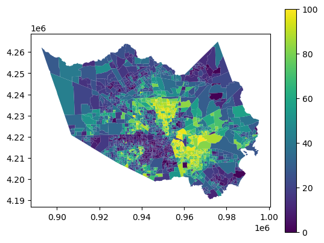

```python
## Calculate percentages of each majority group


bgData["pctAsian"] = bgData.Asian / bgData.Total * 100
bgData["pctBlack"] = bgData.Black / bgData.Total * 100
bgData["pctLatinx"] = bgData.Latinx / bgData.Total * 100
bgData["pctWhite"] = bgData.White / bgData.Total * 100

bgData.plot(column='pctLatinx', legend=True)
```

```python
## Create majority group field

def assign_major_group(row):
    if row['pctAsian'] >= 60:
        return 'Asian'
    elif row['pctBlack'] >= 60:
        return 'Black'
    elif row['pctLatinx'] >= 60:
        return 'Latinx'
    elif row['pctWhite'] >= 60:
        return 'White'
    else:
        return 'Mixed'

bgData['majorGrp'] = bgData.apply(assign_major_group, axis=1)

bgData.head(10)
```

|  | GEOID | geometry | Total | White | Black | Asian | Latinx | pctAsian | pctBlack | pctLatinx | pctWhite | majorGrp |
| --- | --- | --- | --- | --- | --- | --- | --- | --- | --- | --- | --- | --- |
| 0 | 482013110001 | POLYGON ((958404.137 4217699.295, 958413.144 4... | 583 | 0 | 0 | 0 | 583 | 0.000000 | 0.000000 | 100.000000 | 0.000000 | Latinx |
| 1 | 482013110004 | POLYGON ((957048.814 4217692.784, 957496.427 4... | 1869 | 22 | 0 | 0 | 1847 | 0.000000 | 0.000000 | 98.822900 | 1.177100 | Latinx |
| 2 | 482013111001 | POLYGON ((958975.179 4217311.881, 958892.738 4... | 1046 | 11 | 0 | 0 | 1035 | 0.000000 | 0.000000 | 98.948375 | 1.051625 | Latinx |
| 3 | 482013111003 | POLYGON ((958773.280 4216120.376, 959779.865 4... | 1639 | 112 | 0 | 0 | 1527 | 0.000000 | 0.000000 | 93.166565 | 6.833435 | Latinx |
| 4 | 482013111004 | POLYGON ((958756.220 4216618.402, 959659.603 4... | 1759 | 0 | 16 | 32 | 1711 | 1.819215 | 0.909608 | 97.271177 | 0.000000 | Latinx |
| 5 | 482013131001 | POLYGON ((948490.088 4214006.390, 948838.150 4... | 2744 | 1567 | 347 | 434 | 375 | 15.816327 | 12.645773 | 13.666181 | 57.106414 | Mixed |
| 6 | 482013111002 | POLYGON ((958538.363 4215935.056, 958611.621 4... | 1092 | 7 | 0 | 0 | 1085 | 0.000000 | 0.000000 | 99.358974 | 0.641026 | Latinx |
| 7 | 482013131002 | POLYGON ((947852.561 4213019.383, 947966.900 4... | 652 | 304 | 85 | 119 | 88 | 18.251534 | 13.036810 | 13.496933 | 46.625767 | Mixed |
| 8 | 482015431001 | POLYGON ((896848.263 4250165.408, 897077.183 4... | 3498 | 1442 | 322 | 19 | 1490 | 0.543168 | 9.205260 | 42.595769 | 41.223556 | Mixed |
| 9 | 482015502001 | POLYGON ((943861.867 4241534.858, 944139.303 4... | 2256 | 143 | 1368 | 0 | 745 | 0.000000 | 60.638298 | 33.023050 | 6.338652 | Black |

```python
## Group by majority groups and dissolve geometry
bgData['blockGroups'] = 1
#bgData['majorGrp2'] = bgData.majorGrp
group_sums = bgData.groupby('majorGrp')[['blockGroups', 'Total', 'White', 'Black', 'Asian', 'Latinx']].sum().reset_index()

# Step 2: Merge the sum information with the original GeoDataFrame
bgDataWithSums = pd.merge(bgData, group_sums, on='majorGrp', how = 'inner')

# Step 3: Dissolve based on 'majorGrp' and calculate the sum
dissolved = bgDataWithSums.dissolve('majorGrp', aggfunc='sum')

# Step 4: Create a new GeoDataFrame with the dissolved result
major_grps = gpd.GeoDataFrame(dissolved)

major_grps = major_grps.drop(columns=['blockGroups_y','Total_y','White_y','Black_y','Asian_y','Latinx_y'])

major_grps.rename(
  columns={
    'blockGroups_x': 'blockGrps',
    'Total_x' : 'Total',
    'White_x' : 'White',
    'Black_x' : 'Black',
    'Asian_x' : 'Asian',
    'Latinx_x' : 'Latinx'
  },
  inplace=True
)

major_grps.head()

#bgData.plot(column='majorGrp', legend=True)
```

| majorGrp | geometry | Total | White | Black | Asian | Latinx | pctAsian | pctBlack | pctLatinx | pctWhite | blockGrps |
| --- | --- | --- | --- | --- | --- | --- | --- | --- | --- | --- | --- |
| Asian | MULTIPOLYGON (((926751.990 4209490.058, 926783... | 3814 | 557 | 157 | 2431 | 637 | 192.226138 | 16.971301 | 47.205665 | 41.411103 | 3 |
| Black | MULTIPOLYGON (((949698.842 4206031.461, 949639... | 264578 | 10961 | 199801 | 3261 | 47251 | 180.146080 | 13451.646456 | 3023.093058 | 650.237696 | 175 |
| Latinx | MULTIPOLYGON (((965411.937 4198913.656, 965055... | 1219893 | 112180 | 109390 | 27012 | 962544 | 1195.685395 | 4933.749778 | 51520.813364 | 6210.126096 | 643 |
| Mixed | MULTIPOLYGON (((970393.326 4194192.233, 969688... | 2213832 | 661709 | 497957 | 224801 | 777050 | 8318.759023 | 19525.925998 | 30700.430404 | 25805.788462 | 864 |
| White | MULTIPOLYGON (((978544.008 4193972.941, 978565... | 823402 | 601169 | 30980 | 49604 | 123053 | 2669.432784 | 1483.902465 | 6311.791195 | 34404.114891 | 459 |

### Analysis

Describe the methods of analysis that will directly test the hypotheses or provide results to answer the research questions. This section should explicitly define any spatial / statistical *models* and their *parameters*, including *grouping* criteria, *weighting* criteria, and *significance thresholds*. Also explain any follow-up analyses or validations.

#### Goal 3: Find flooded area in each group and calculate pct

```python
# Zonal Statistics

# Filter out invalid geometries
major_grps = major_grps[major_grps.geometry.is_valid]

major_grps.to_file(here(path["ddpub"],'major_grps.shp'), driver='ESRI Shapefile')


# Specify the path to the raster file
raster_file = here(path["drpub"],'actual_flood_10.tif')

# Read raster data using rasterio
with rasterio.open(raster_file) as src:
    # Get raster values as a NumPy array
    raster_data = src.read(1)


with fiona.open(here(path["ddpub"],'major_grps.shp')) as src:
    zs = zonal_stats(src, raster_file, stats="count", all_touched=True)


print(zs)

flood_pixels = [value for dictionary in zs for value in dictionary.values()]

bgMajorFld = gpd.read_file(here(path["ddpub"],'major_grps.shp'))

bgMajorFld['fl_count'] = flood_pixels

# Display the GeoDataFrame with the new "flood" column
print(bgMajorFld['fl_count'])
```

```
[{'count': 2165}, {'count': 645888}, {'count': 3181885}, {'count': 11415356}, {'count': 4784908}]
0        2165
1      645888
2     3181885
3    11415356
4     4784908
Name: fl_count, dtype: int64
```

```python
# Field Calculator Flooded Area
bgMajorFld['flArea'] = bgMajorFld.fl_count * 10 * 10
bgMajorFld['totArea'] = (bgMajorFld.geometry.area).round(2)
bgMajorFld['pctFlood'] = (bgMajorFld.flArea / bgMajorFld.totArea * 100).round(2)

bgMajorFld.head()

columns_to_export = ['majorGrp', 'blockGrps','flArea', 'totArea', 'pctFlood']

bgMajorFld[columns_to_export].to_csv(here(path["rtab"],'MajGrpFld.csv'), index=False)

bgMajorFld.to_csv(here(path["ddpub"],'bgMajorFld.csv'), index=False)
```

## Results

The final results for this study are the Final Table which shows number of block groups, flooded area, total area, and percent flooded in each majority group region. The other results are a map of percent flooding by each region, and maps of the majority group regions and the flooding.

```python
# Final Table
Final_Table = pd.read_csv(here(path["rtab"],'MajGrpFld.csv'), dtype=str,encoding='latin-1')
Final_Table.head()
```

|  | majorGrp | blockGrps | flArea | totArea | pctFlood |
| --- | --- | --- | --- | --- | --- |
| 0 | Asian | 3 | 216500 | 952855.79 | 22.72 |
| 1 | Black | 175 | 64588800 | 206749828.71 | 31.24 |
| 2 | Latinx | 643 | 318188500 | 789346589.94 | 40.31 |
| 3 | Mixed | 864 | 1141535600 | 2477275416.41 | 46.08 |
| 4 | White | 459 | 478490800 | 1114263551.36 | 42.94 |

The final table shows how most of the flooding ocurred in the regions that did not have a dominant racial/ethnic group. However, this region had the most number of block groups and most total area. The majority groups that had the highester percentage of area flooded were White and Latinx. This final table should be close to the same as the final table from the original study. The only differences were the exact flooded area numbers which were calculated using different zonal statistic tools. The final flood percentages were very close to the originals.

```
Percent Flooded by Block Groups
```

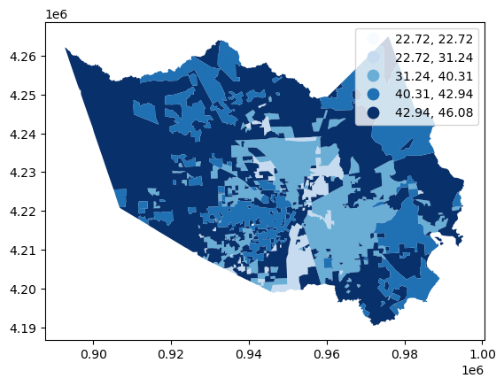

```python
# Final Map
Final_Map = bgMajorFld.plot(column = 'pctFlood', legend = True, cmap = 'Blues', scheme = 'FisherJenks')
print("Percent Flooded by Block Groups")

plt.savefig(here(path["rfig"],'bgMajorFld.png'))
```

#### Percent Flooded by Block Groups

This map is designed to match the final map from the original study. It shows the percentage flooded in each majority group. Besides small stylistic elements it matches the original.

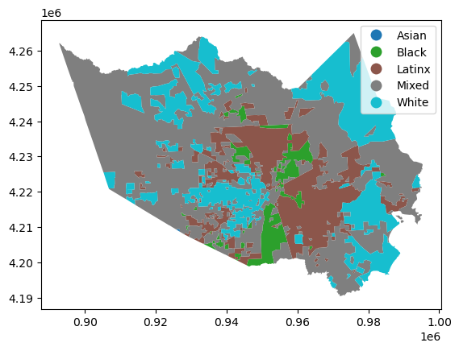

```python
# Map of Majority Groups
bgMajorFld.plot(column='majorGrp', legend = True)
plt.savefig(here(path["rfig"],'majorGrps.png'))
```

#### Majority Groups in Harris County, Texas

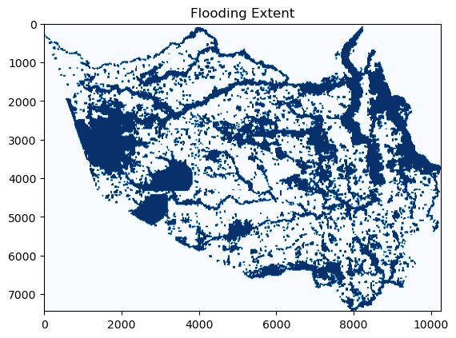

```python
# Map of Flooding Extent

with rasterio.open(here(path["drpub"],'actual_flood_10.tif')) as src:
    # Read the raster data
    raster_data = src.read(1)

    # Plot the raster image
    plt.imshow(raster_data, cmap='Blues')
    #plt.colorbar(label='Pixel Values')
    plt.title('Flooding Extent')

    # Save the plot as a PNG file
    plt.savefig(here(path["rfig"],'actualFlood.png'))

    # Show the plot (optional)
    plt.show()
```

#### Flooding extent from Hurricane Harvey in Harris County, Texas

The previous two maps are designed to fill the place of another map deliverable from the original study. The original study produced a map of majority groups with a flooding layer on top. This reproduction was not able to replicate this specific figure but the two previous figures show the same layers.

## Discussion

The success of both the original study and this replication are both challenging to evaluate given the design of the study as an educational problem. The scientific research question is the evaluation of the environmental justice and spatial patterns of flooding from Hurricane Harvey. The reproduction found the same patterns and similar percentage flooded as the original study. Both studies found the highest percentage of flooding in Mixed majority group regions, followed by White and Latinx regions. In this regard, the reproduction was a success. The main goal was to translate the existing QGIS workflow into python code in a way that this notebook could be used as a learning example in future courses teaching python as a GIS tool. This reproduction succesfully translated each data fransformation and analysis step into reproducible python code. The visualization of results is not entirely complete, and further reproductions of this study could improve it through visualization and cartography in python. However, this computational notebook successfully implements a simple GIS problem in a reproducible way and can serve as a building block for future python for GIS educational projects.

## Integrity Statement

The authors of this preregistration state that they completed this preregistration to the best of their knowledge and that no other preregistration exists pertaining to the same hypotheses and research.

# Acknowledgements

This project was made possible as part of the Middlebury Geography course Open Source GIScience taught by Professor Joseph Holler.

This report is based upon the template for Reproducible and Replicable Research in Human-Environment and Geographical Sciences, DOI:10.17605/OSF.IO/W29MQ

## References

Middlebury Geography Department